# Log-Linear Poisson Graphical Model with Hot-Deck Multiple Imputation

Nathalie Villa-Vialaneix

MIAT, Université de Toulouse, INRA, Castanet-Tolosan, France

Alyssa Imbert

MIAT, Université de Toulouse, INRA, Castanet-Tolosan, France

Abstract

Tutorial on how to use the *RNAseqNet* package to infer networks from RNA-seq expression datasets with or without an auxiliary dataset.

# Introduction

The **R** package `RNAseqNet` can be used to infer networks from RNA-seq expression data. The count data are given as a $n \times p$ matrix in which $n$ is the number of individuals and $p$ the number of genes. This matrix is denoted by $\mathbf{X}$ in the sequel.

Eventually, the RNA-seq dataset is complemented with an $n' \times d$ matrix, $\mathbf{Y}$ which can be used to impute missing individuals in $\mathbf{X}$ as described in [Imbert *et al.*, 2018][^1].

# Dataset description

Two datasets are available in the package: `lung` and `thyroid` with $n = 221$ rows and respectively 100 and 50 columns. The raw data were downloaded from https://gtexportal.org/. The TMM normalisation of RNA-seq expression was performed with the **R** package `edgeR`.

Data are loaded with:

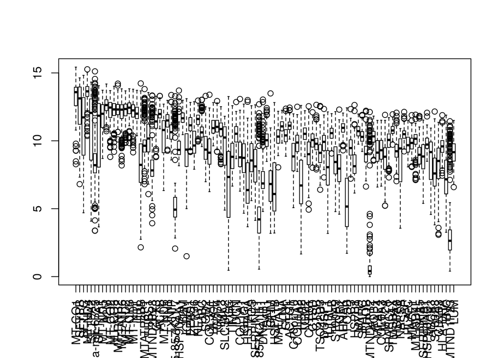

```r
data(lung)
boxplot(log2(lung + 1), las = 3, cex.names = 0.5)
```

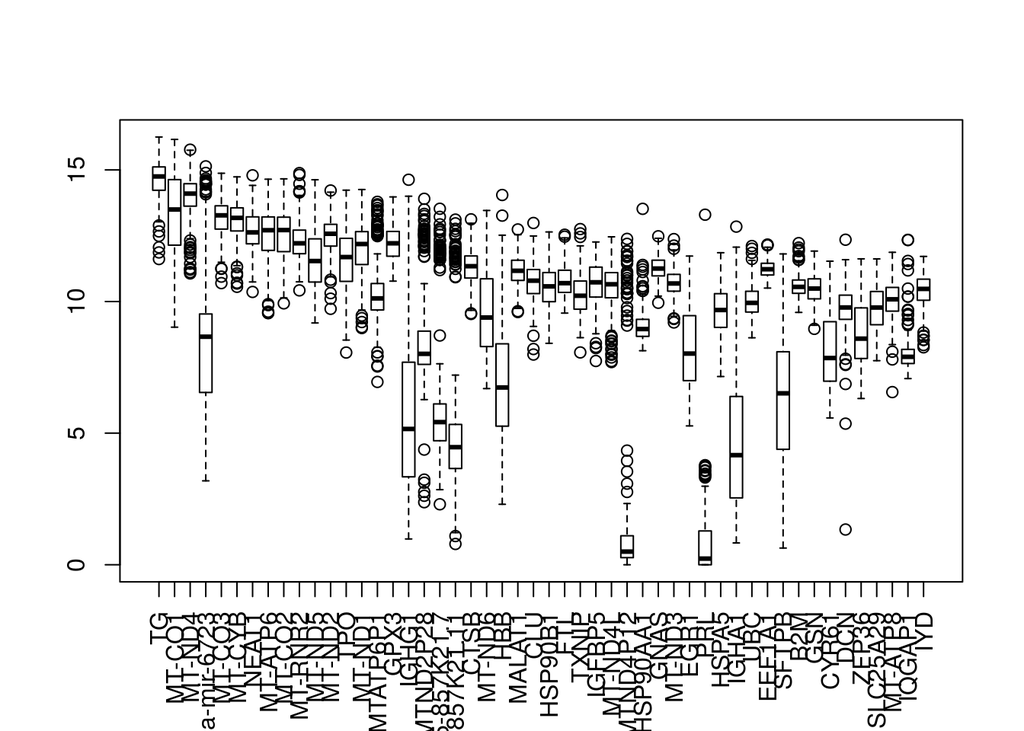

```r
data(thyroid)
boxplot(log2(thyroid + 1), las = 3, cex.names = 0.5)
```

# Network inference from RNA-seq data

Network inference from RNA-seq data is performed with the Poisson GLM model described in [Allen and Liu, 2012][^2]. The inference can be performed with the function `GLMnetwork` as follows:

```r
lambdas <- 4 * 10^(seq(0, -2, length = 10))
ref_lung <- GLMnetwork(lung, lambdas = lambdas)
```

The entry `path` of `ref_lung` contains `length(lambdas)` = 10 matrices with estimated coefficients. Each matrix is a square matrix with `ncol(lung)` = 100 rows and columns.

The choice of the most appropriate value for $\lambda$ can be performed with the StARS criterion of [Liu *et al.*, 2010][^3], which is implemented in the function `stabilitySelection`. The argument `B` is used to specify the number of re-sampling used to compute the stability criterion:

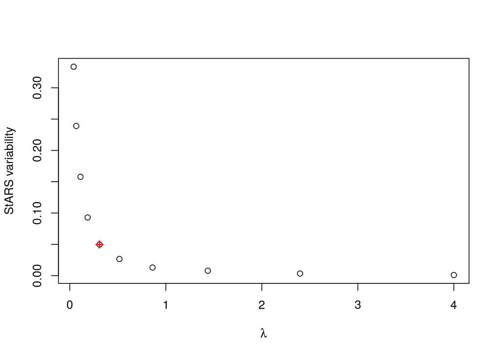

```r
set.seed(11051608)
stability_lung <- stabilitySelection(lung, lambdas = lambdas, B = 50)
plot(stability_lung)
```

The entry `best` of `stability_lung` is the index of the chosen $\lambda$ in `lambdas`. Here, the value $\lambda=$ `lambdas[stability_lung$best]` = 0.3097055 is chosen.

The corresponding set of estimated coefficients, is in `ref_lung$path[[stability_lung$best]]` and can be transformed into a network with the function `GLMnetToGraph`:

```r
lung_refnet <- GLMnetToGraph(ref_lung$path[[stability_lung$best]])
print(lung_refnet)
```

```
## IGRAPH dcc3d30 UN-- 100 454 --
## + attr: name (v/c)
## + edges from dcc3d30 (vertex names):
##  [1] MT-CO1--MT-ND4       MT-CO1--SFTPA2       MT-CO1--hsa-mir-6723
##  [4] MT-CO1--A2M          MT-CO1--MT-CO2       MT-CO1--MT-CO3
##  [7] MT-CO1--MT-RNR2      MT-CO1--MT-ATP6      MT-CO1--MT-ND1
## [10] MT-CO1--MTND2P28     MT-CO1--MT-ND6       MT-CO1--SAT1
## [13] MT-CO1--HSPB1        MT-CO1--MTND4P12     MT-CO1--HLA-DRA
## [16] MT-CO1--MTND1P23     SFTPB --SFTPA2       SFTPB --FN1
## [19] SFTPB --B2M          SFTPB --NEAT1        SFTPB --SLC34A2
## [22] SFTPB --PGC          SFTPB --CTSD         SFTPB --TSC22D3
## + ... omitted several edges
```

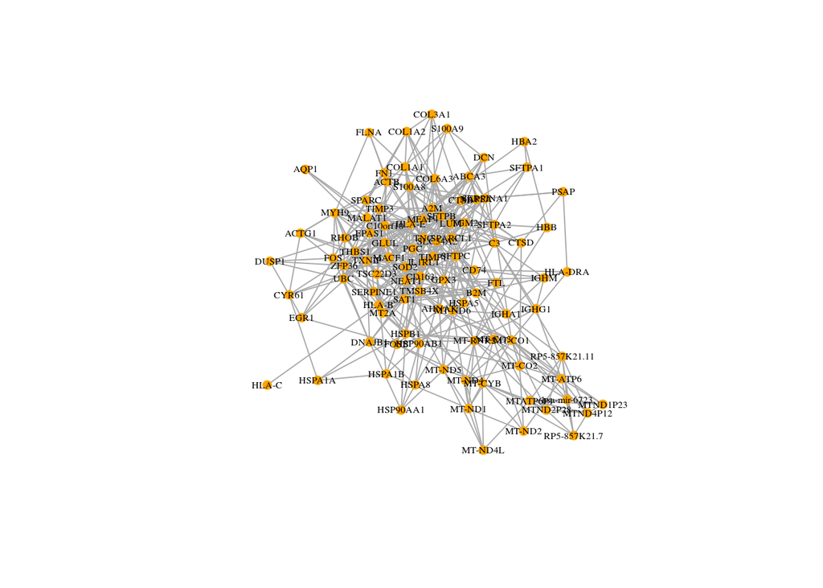

```r
set.seed(1243)
plot(lung_refnet, vertex.size = 5, vertex.color = "orange",
     vertex.frame.color = "orange", vertex.label.cex = 0.5,
     vertex.label.color = "black")
```